# DataExplorer

Sally Heo

4/10/2022

## Load libraries and data

```r
library(tidyverse) #Load tidyverse
library(here) #Load here
library(DataExplorer) #Load DataExplorer
library(ggthemes) #Load ggthemes
```

## Load Data

```r
chem <- read_csv(here("DataExplorer", "data", "chemicaldata_maunalua.csv"))
View(chem)
```

## Function: plot_correlation

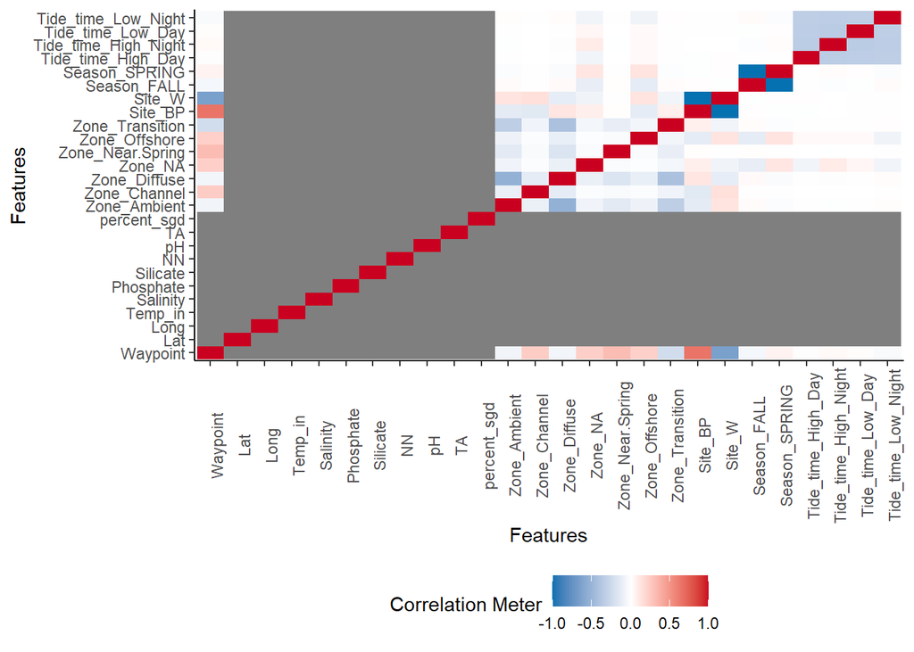

```r
plot_correlation(chem,#Input the data, in this case it is chem
                 type = c("all", "discrete", "continuous"), #The column types to be included in the correlation plot; "All" = all columns, "discrete" is for discrete features, "continuous" is for continuous.
                 maxcat = 20L, #Maximum categories allowed for each discrete feature
                 cor_args = list(),# List of arguments to be passed to the plot correlation function
                 geom_text_args = list(), #List of arguments to geom_text
                 title = NULL, #Plot title, NULL is the default (no title)
                 ggtheme = theme_classic(), #Setting theme_classic
                 theme_config = list(legend.position = "bottom", axis.text.x = element_text(angle = 90))#Adjusting axis text, and legend position
                 )
```

## Function(a): create_report()

- This function creates a data profiling report for our Chem Data
- Organizes the data profiling statistics into a report
- This is a really important function and runs most of the explatory data analysis (EDA) functions and gives a output html file.

## Function (b): configure_report()

- This function allows us to customize each individual section of the data profiling report
- We can turn off sections of the data report that we don’t want to show
- We can also set a global theme
- For example for add_plot qq = FALSE, if we change FALSE to TRUE, the qq plot will be included in the data profiling report.
- We can also configure a report where only QQ and box plots are included and the correlation analysis is not added.

## Arguments

- add_plot_qq: Specifies whether or not the QQ plot is added in the report
- add_plot_boxplot: Specifies whether or not the boxplot is added in the report
- add_plot_histogram: Specifies whether or not the histogram is added to the report
- add_plot_correlation: Specifies whether or not the correlation analysis is added to the report
- global_ggtheme: The global setting and to set the theme of the report (ie theme_minimal, theme_gray, theme_few)

```r
config <- configure_report( #config argument, the report configuration generated by configure_report
  add_plot_qq = TRUE, #Show qq plot in the data profiling report
  add_plot_boxplot = TRUE, #show the boxplot in the data profiling report
  add_plot_histogram = TRUE, #show the histogram in the data profiling report
  add_plot_correlation = TRUE, #show the correlation analysis in the data profiling report
  global_ggtheme = quote(theme_gray(base_size = 14)) #Setting global setting for the theme of the report
)
create_report(chem, config = config) #creates a data profiling report
```

```
##
##
## processing file: report.rmd
```

[output not shown]

[output not shown]

[output not shown]

[output not shown]

[output not shown]

[output not shown]

[output not shown]

[output not shown]

```
## output file: C:/Users/Twilight/Repositories/DataExplorer/DataExplorer/script/report.knit.md
```

[output not shown]

```
##
## Output created: report.html
```